# Paths to HD/BOLD Detectors

JJ, NEXT-CM, January 2025

## HD Design Drivers

- **Physics**
  - Best possible energy resolution (imply best possible calibration, control of systematics)
  - Performance of topological signature (physics, diffusion, pitch).
- **Radiopurity**
  - Dominated by copper
  - Minimize radioactive budget inside the copper shield.
  - Electronics radioactive budget to be taken into account.
- **Others**
  - R&D on grids.
  - Understanding light collection.
- **BOLD constrains**
  - Use of TPB **may** be disfavoured (we need proof).

## Current HD Baseline (HDB) design

- Two ("dense") silicon planes, one per anode (**DTPs**).
- Barrel Fiber Detector (**BFD**) readout by cooled SiPMs.

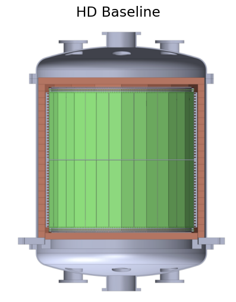

Detector parameters at P=15 bar, T= 20C

- R = 1.3 mm; L = 2.6 m

- Area barrel =21.24 m2

- Area end-cap =5.31 m2

- Volume= 13.80 m3

- $\rho$ =89.90 kg/m3

- mass = 1241.0 kg

Detector EL parameters at P=15 bar, T= 20C

- E/P = 1.30 kV * cm$^{-1}$* bar$^{-1}$

- Drift voltage = 0.50 kV * cm$^{-1}$

- EL grid gap = 10.00 mm

- Drift lenght = 1.30 m

- Grid voltage = 19.50 kV

- Cathode voltage = 84.50 kV

- Yield = 9.90e+02 photons/e

S1 and S2 photons for Kr and $Q_{\beta\beta}$

- Primary scintillation Krypton = 1.04e+03

- EL photons Krypton = 1.88e+06

- Primary scintillation $Q_{\beta\beta}$ = 6.15e+04

- EL photons $Q_{\beta\beta}$ = 1.11e+08

## Dark Current considerations

- Let us examine first the dependence of the dark current rate (dcR) of SiPMs with temperature.
- We take as model the modern, low DC, Hamamatsu data S13360 series

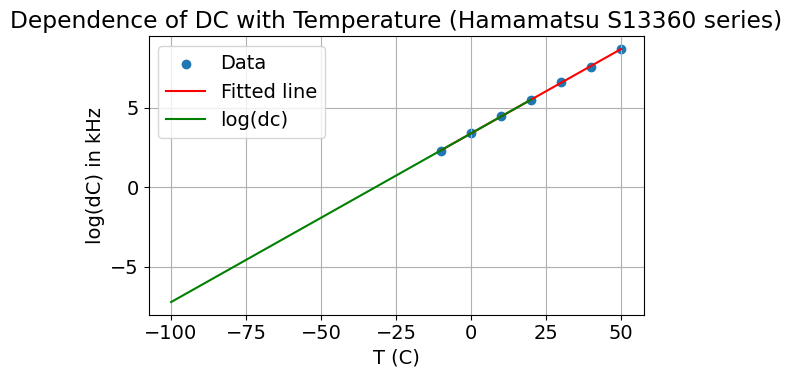

## The BFD

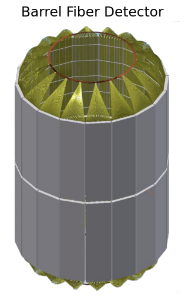

Light efficiency collection S1

- Fibers efficiency = 3.54 %

  - Transport = 4.26 %

  - Attenuation = 83.05 %

- SiPM PDE = 40.00 %

- Total detection efficiency = 1.4 %

- Sampling S1 = 100.0 ns

- Operating temperature (-20.0 C)

- Primary scintillation Krypton = 1.04e+03

- Primary scintillation Krypton detected = 14.7

- Number of DCR photons in the detector = 0.33

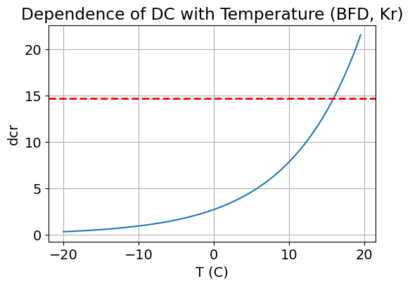

- Operation of SiPMs at -20C results in negligible DCR
- Krypton S1 clearly observable

## Dynamic Range for fibers

Dynamic range for fiber detector

- Minimum diffusion ~15.0 mus.

- Sampling: 25.0 ns.

- Thus: number of samples = 600

- N$_\gamma$ (blob) = 13561643

- N$_\gamma$ (sample) = 22602

- N$_\gamma$ (max/sector) = 1017

- Cutting at Rf = 0.95

- N$_\gamma$ (Rf) = 495

- PES for 13 bit ADC = 546

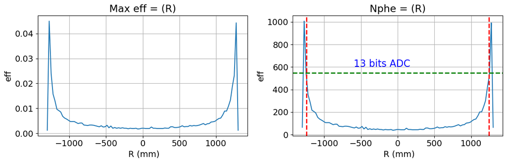

## Cost of BFD

| Item | Quantity | Cost (€) |
| --- | --- | --- |
| Fibers | 19.5 km | 74,100 |
| SiPMs | 504 | 15,400 |
| Electronics | 504 | 5,040 |
| Total |  | 94,540 |

## DTP (the Blue version)

- Maximum feasible size of SiPMs (both from the point of view of ASIC and dynamic range: 6 x 6 mm2).
- DTP can be "fully tiled" (fDTP, e.g., SiPMs of 6 x 6 mm2 at a pitch of 6 mm) or "partial coverage" (xDTP, e.g., 6x6 mm2 at a pitch of say, 10 mm).
- Let's consider first the case of a fDTP

DTP

- Pressure = 15 bar

- Temperature = 20 C

- Filling factor = 1.0

- area = 5.3e+06 mm$^2$,

- number of SiPMs = 1.47e+05

- Light efficiency (s1) = 1.54 %

- Light efficiency (s2) = 5.85 %

- SiPM (efective) PDE = 0.13

- SiPM size = 6.00 mm

- Sampling S1 = 500.00 ns

- Primary scintillation Qbb keV detected = 9.55e+02

- EL photons $Q_{\beta\beta}$ detected = 6.50e+06

- nDCR = 1.47e+05

- S1 cannot be observed with DTP at ambient temperature

Dynamic range for DTP detector

- Assume $E_b \sim$ 300.0 keV

- Minimum diffusion ~15.0 mus.

- Sampling: 0.5 mus.

- Thus: number of samples = 30

- N$_\gamma$ (blob) = 13561643

- N$_\gamma$ (sample) = 452054

- N$_\gamma$ (SiPM) = 526

- PES for 13 bit ADC = 744

- The dinamic range (for the worst case) is OK

## Power dissipation

Power dissipation in DTP

- number of SiPMs in fDTP =294960

- number of ASICS in fDTP =4609

- number of readout tiles = 577

- power per readout tiles = 14.0 watt

- Total Power to dissipate = 8.08e+03 watt

## Power dissipation requires pDTP

- The fDTP dissipates more than 8kW! Very hard to evacuate it!
- Also: electronic channels, throughput, cost
- Need to consider a DTP with partial coverage (pDTP)
- For example, 6 x 6 mm2 at a pitch of 10 mm.

## The pDTP

DTP

- Temperature = 20 C

- Filling factor = 0.36

- area = 5.3e+06 mm$^2$,

- number of SiPMs = 5.31e+04

- Light efficiency (s1) = 0.55 %

- Light efficiency (s2) = 2.11 %

- SiPM (efective) PDE = 0.13

- SiPM size = 6.00 mm

- Sampling S1 = 500.00 ns

- Primary scintillation Qbb keV detected = 3.44e+02

- nDCR = 5.31e+04

- Neither fDTP nor pDTP can detect S1 (including $Q_{\beta\beta}$) S1, but S2 enough for good resolution

Power dissipation in DTP

- number of SiPMs in fDTP =106185

- number of ASICS in fDTP =1660

- number of readout tiles = 208

- power per readout tiles = 14.0 watt

- Total Power to dissipate = 2.91e+03 watt

- Power dissipation ~3 kwatt is challenging
- But the detector will be immersed in water, thus a combination of liquid cooling and cold links to the vessel may work.

## Cost of Dense Tracking Plane

Cost of DTP

- cost of SiPMs = 4.11 M€

- cost of electronics = 1.59 M€

- Total = 5.70 M€

## Outlook: HD baseline

- HD baseline appears as a sound approach for a ton scale detector.
- Technical solutions exist now and can be implemented at a scale in a period of ~5 years including demonstrators.
- Substantial challenges, including power dissipation and radiopurity (electronics).
- BFD can provide trigger, S1 and an energy measurement.
- pDTP can provide tracking and a second energy measurement.
- Combination of two energy measurements likely to improve resolution.
- Cost dominated by Silicon but still modest

## Ultra Violet HD (UVHD)

- No TPB allowed. This leads naturally to a detector based on "VUV SiPMs" (**vSiPMs**).
- The most feasible option is a detector with two pDTPs (one per anode).
- Options with fDTP appear unrealistic (power dissipation, cost). Barrel instrumentation also unrealistic.

## Operating temperature and pressure

- Detection of S1 at $Q_{\beta\beta}$ is a must, and arguably one would like to detect also S1 for calibration sources at 511 keV.
- This will require to cool SiPMs (to ~ -40 C as shown below), adding complexity to the problem of evacuating the electronics power
- Likely, the simplest way to do that is to operate with cold gas, and keep the whole system at some -40 C.
- This has advantages. At P=15 bar, T=-40C, the detector has the same density than a detector operating at P=20 bar and T=20C. Consequently the transverse dimensions of the detector can be reduced (and thus the number of SiPMs).

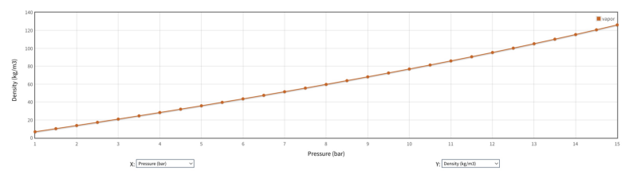

## VUV-HD (No TPB)

Detector parameters at P=15 bar, T= m40C

- R = 1.1 mm; L = 2.2 m

- Area barrel =15.21 m2

- Area end-cap =3.80 m2

- Volume= 8.36 m3

- $\rho$ =126.00 kg/m3

- mass = 1053.7 kg

Detector EL parameters at P=15 bar, T= m40C

- E/P = 1.20 kV * cm$^{-1} \times$ bar$^{-1}$

- Drift voltage = 0.50 kV $\times$ cm$^{-1}$

- EL grid gap = 10.00 mm

- Drift lenght = 1.10 m

- Grid voltage = 24.00 kV

- Cathode voltage = 79.00 kV

- Yield = 1.04e+03 photons/e

## Measuring S1

- At t=-40 C it is possible to detect the S1 signal from 511 keV electrons (Kr S1 cannot be detected) an observe comfortably the signal from Q$_{\beta\beta}$

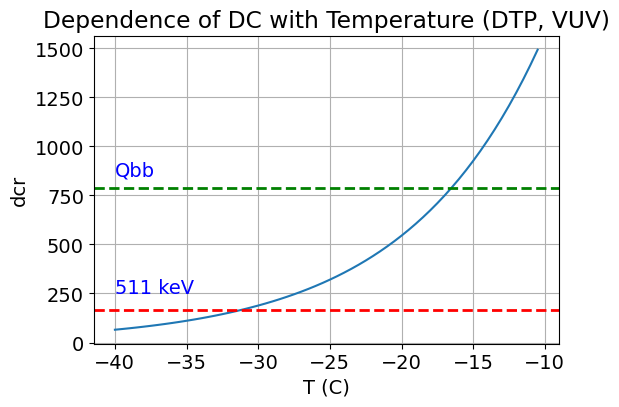

Cost of DTP

- cost of SiPMs = 31.43 M€

- cost of electronics = 1.59 M€

- Total = 33.02 M€

## Outlook: HD VUV

- HD VUV appears also doable, but is more challenging.
- Cooling the detector at t=-40 requires likely cold gas, and thus adding the complexity of a cryostat.
- S1 can be measured for calibration sources having at least 511 keV (e.g., Na$^{22}$)
- pDTP provide both tracking and energy measurement.
- Substantially higher cost but SiPM VUV cost may go down in the future.

## A path forward towards discovery: NEXT-100

- NEXT-100 operation limited by PMTs (e.g., pressure problem). Will eventually be fixed but not in a fully satisfactory way.
- Initial measurement of light collection shows an efficiency of 0.5 % (which however allows us to see Krypton!).
- In spite of these limitations, the detector seems in good shape. We should fully exploit its potential in the next 2-3 years.

## A path forward towards discovery: HD-DEMO

- HD-DEMO can test the performance of BFD and DTP. The prototype is large enough to provide a good measurement of energy and tracking in the double escape peak of Tl, as well as a full energy calibration, from Kr to Tl.
- HD-DEMO is being prepared to operate with a tracking plane and electronics recycled from NEXT-White. The first phase of HD-DEMO operation (~2025) would asess the performance of the simplest configuration.
- During HD-Demo phase I, we should build a DTP with the goal of operating it in 2026-2027, using the new ASIC and electronics.

## A path forward towards discovery: NEXTU2

- NEXTU1: minimal upgrade with respect to NEXT-100.
  - A new (fresly coated) BFD which hopefully will retire PMTs and show good light colleciton efficiency (a factor 3 w.r.t. NEXT-100 today).
  - New front-end electronics and DAQ, as discussed in this meeting.
  - Spanish groups are requesting funds for U1, with the plan of installing the upgrades in 2028 -NEXTU2: Replaces the current tracking plane by a pDTP (e.g., SiPMs of 6 x 6 mm2).
- U2 would offer a great opportunity for new collaborators to join the DTP effort (get the pun?)
- NEXTU2 is a large-scale prototype of NEXT-HD

## NEXTU2: A multiverse variant

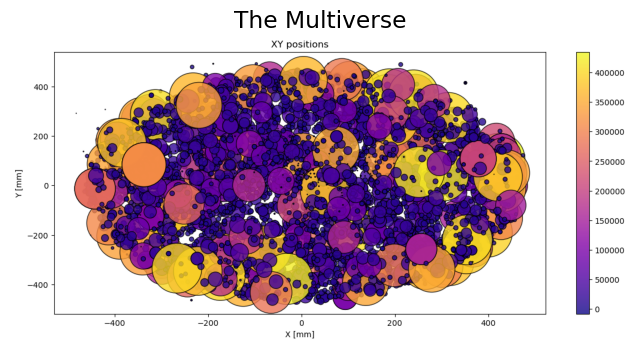

- There is more enriched xenon around (e.g., 200 kg from EXO). Thus, a total of 300 kg could be available already.
- A symmetric detector (two TPCs) with the same radius of NEXT-100 and the same length (per TPC) of HD operating at 20 bar would accomodate ~250 kg of xenon.
- NEXTU2 could be an intermediate detector, fully trying the HD baseline. It would be an even better step that the NEXT-100 upgrades (notices that NEXTU2 does not contain numbers). If the collaboration is expanded to include you-know-who, we could start planning NEXTU2, **today** while we operate NEXT-100, and skip the upgrades of NEXT altogether (we would aim to building NEXTU2 in 3-5 years).
- This is (for a while) compatible with the Spanish groups proposal for funding, since we are asking money to build components of a detector (BFD, ASICs, DAQ) which could be accommodated in a larger detector.
- And of course it would be a great bait for new collaborators.

## A path forward towards discovery: NEXT-Zen

- The KamLAND-Zen collaboration owns 800 kg of Xenon and are interested in a future "NEXT-Zen" detector after completing the operation of the upgraded KamLAND-Zen.
- The approximate "t0" for NEXT-Zen would be 2032. Thus, this possibility is compatible with NEXTU2.
- NEXT-Zen could be a realisation (with 1.3 tons of Xenon) of HD baseline and achieve a sensitivity $>10^{27}$ y by 2040.

## A path forward towards discovery: BOLD

- As shown, a detector ready for Barium Tagging (without TPB) is doable, using VUV-DTPs.
- Cost and complexity is considerable, and Barium Tagging is not yet around the corner.
- However, if (and when) Barium Tagging is fully demonstrated, one could start building such a detector.
- Given the time uncertainties and the fact that the HD baseline costs a fraction of the cost of BOLD, the best strategy is simply to assume separated modules.

## A path forward towards discovery: White paper

- We should produce a document that acts both as a roadmap and as an advertising brochure for potential collaborators.
- We have been invited to an important summit in May. Presumably, the news of nEXO passing will impact the field and redefine the role of the rest of the experiments. NEXT, in particular, can benefit from the new situation.
- However, by May, we should show sizeable progress. It is imperative to complete the low energy run by then and start the fixing of the energy plane.
- I also propose to write a White Paper describing a path to discovery, as outlined above including NEXT-100 operation, HD-DEMO N100U2 (including multiverse version), NEXT-HD (Zen) and NEXT-BOLD.
- While such a White Paper will not be a detailed CDR, it will provide a reference document, a declaration of intentions, and a propaganda brochure for new collaborators.

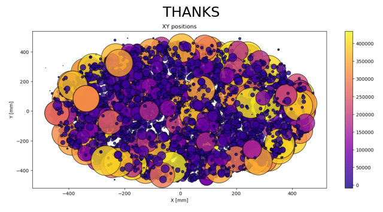